# Comentários e cultura

```r
dados = read_csv(
    here::here("data/participation-per-country.csv"),
    col_types = cols(
        .default = col_double(),
        site = col_character(),
        country = col_character(),
        geo = col_character(),
        four_regions = col_character(),
        eight_regions = col_character(),
        six_regions = col_character(),
        `World bank income group 2017` = col_character()
    )
) %>% filter(usuarios > 250)

filtered <- dados %>%
    filter(!is.na(usuarios),!is.na(Internet),!is.na(comentaram_prop),!is.na(six_regions))

glimpse(dados)
```

```
## Observations: 112
## Variables: 21
## $ site                           <chr> "StackOverflow", "StackOverflow", "S...
## $ country                        <chr> "Argentina", "Australia", "Austria",...
## $ PDI                            <dbl> 49, 36, 11, 80, 65, 69, 70, 39, 63, ...
## $ IDV                            <dbl> 46, 90, 55, 20, 75, 38, 30, 80, 23, ...
## $ MAS                            <dbl> 56, 61, 79, 55, 54, 49, 40, 52, 28, ...
## $ UAI                            <dbl> 86, 51, 70, 60, 94, 76, 85, 48, 86, ...
## $ usuarios                       <dbl> 2798, 12313, 2518, 2558, 4275, 10717...
## $ responderam_prop               <dbl> 0.5357398, 0.6133355, 0.6310564, 0.3...
## $ perguntaram_prop               <dbl> 0.5210865, 0.5897832, 0.5933280, 0.4...
## $ editaram_prop                  <dbl> 0.09256612, 0.14699911, 0.14932486, ...
## $ comentaram_prop                <dbl> 0.2533953, 0.3339560, 0.3502780, 0.1...
## $ GNI                            <dbl> NA, 59570, 48160, 840, 44990, 11630,...
## $ Internet                       <dbl> 51.0, 79.5, 79.8, 5.0, 78.0, 45.0, 5...
## $ EPI                            <dbl> 59.02, NA, 63.21, NA, 61.21, 49.96, ...
## $ geo                            <chr> "arg", "aus", "aut", "bgd", "bel", "...
## $ four_regions                   <chr> "americas", "asia", "europe", "asia"...
## $ eight_regions                  <chr> "america_south", "east_asia_pacific"...
## $ six_regions                    <chr> "america", "east_asia_pacific", "eur...
## $ Latitude                       <dbl> -34.00000, -25.00000, 47.33333, 24.0...
## $ Longitude                      <dbl> -64.00000, 135.00000, 13.33333, 90.0...
## $ `World bank income group 2017` <chr> "Upper middle income", "High income"...
```

Estamos interessados na relação entre quanto as pessoas de diferentes países comentam em questões dos outros. A proporção das pessoas do país que comentou nas questões de outros está medido na variável `comentaram_prop`.

Considerando essa variável, queremos examinar a relação entre ela e o quão hierárquicas são as relações em um país (`PDI`). Queremos também levar em conta o quanto as pessoas daquele país têm acesso à Internet (`Internet`) e qual o tamanho da base de dados que detectamos daquele país (`usuarios`).

## Examinando essa relação

Faça uma visualização que usa os princípios de eficácia no projeto de visualizações para facilitar as comparações que você acha que são as mais importantes para entendermos esse contexto.

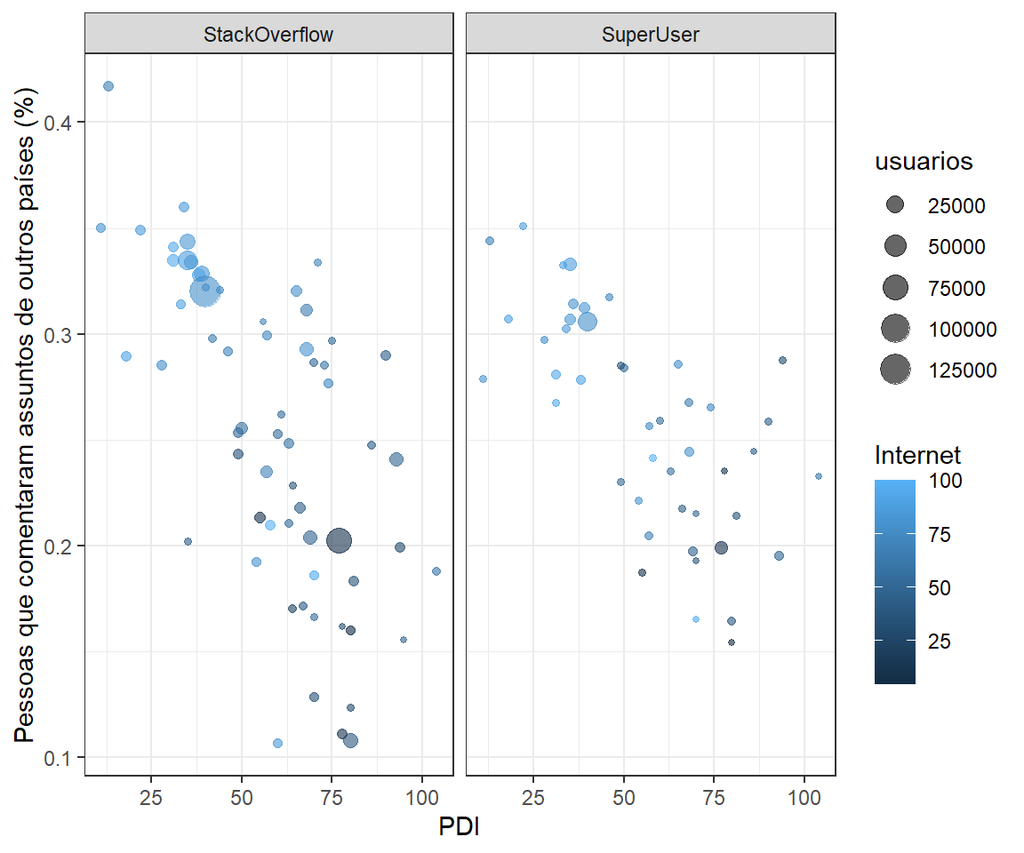

```r
    ggplot(filtered, mapping = aes(x = PDI, y = comentaram_prop, color = Internet, size = usuarios)) +
    geom_point(alpha = .6) +
    facet_grid(~site, scales = "free_x") +
    labs(x = "PDI", y = "Pessoas que comentaram assuntos de outros países (%)")
```

Pelo alinhamento dos pontos no gráfico, pode-se perceber que há alguma relação entre as variáveis com a porcentagem de pessoas que comentaram assuntos de outros. A seguir, vamos calcular os valores de correlação e ver como estas relações se comportam.

#### Correlação **comentaram_prop** e **PDI**

```r
corrPDI <- filtered %>%
    summarise(pearson = cor(comentaram_prop, PDI, method = "pearson"),
              kendall = cor(comentaram_prop, PDI, method = "kendall"),
              spearman = cor(comentaram_prop, PDI, method = "spearman"))
corrPDI
```

```
## # A tibble: 1 x 3
##   pearson kendall spearman
##     <dbl>   <dbl>    <dbl>
## 1  -0.647  -0.484   -0.661
```

Os valores de correlação entre **comentaram_prop** e **PDI** mostram uma relação linear razoável negativamente entre as variáveis, o que indica que quanto maior o número de pessoas que comentaram sobre outros países, menor se torna o PDI, o que indica que as pessoas se esforçam para igualar a distribuição do poder e exigir justificativa para as desigualdades de poder.

#### Correlação filtrado pelo Site “StackOverflow”

```r
corrPDI <- filter(filtered, site=="StackOverflow") %>%
    summarise(pearson = cor(comentaram_prop, PDI, method = "pearson"),
              kendall = cor(comentaram_prop, PDI, method = "kendall"),
              spearman = cor(comentaram_prop, PDI, method = "spearman"))
corrPDI
```

```
## # A tibble: 1 x 3
##   pearson kendall spearman
##     <dbl>   <dbl>    <dbl>
## 1  -0.652  -0.509   -0.668
```

#### Correlação filtrado pelo Site “SuperUser”

```r
corrPDI <- filter(filtered, site=="SuperUser") %>%
    summarise(pearson = cor(comentaram_prop, PDI, method = "pearson"),
              kendall = cor(comentaram_prop, PDI, method = "kendall"),
              spearman = cor(comentaram_prop, PDI, method = "spearman"))
corrPDI
```

```
## # A tibble: 1 x 3
##   pearson kendall spearman
##     <dbl>   <dbl>    <dbl>
## 1  -0.678  -0.488   -0.689
```

Separadas por site as correlações são quase as mesmas, então os tipos de site não tem muita influencia na correlação geral.

```r
corrNet <- filtered %>%
    summarise(pearson = cor(comentaram_prop, Internet, method = "pearson"),
              kendall = cor(comentaram_prop, Internet, method = "kendall"),
              spearman = cor(comentaram_prop, Internet, method = "spearman"))
corrNet
```

```
## # A tibble: 1 x 3
##   pearson kendall spearman
##     <dbl>   <dbl>    <dbl>
## 1   0.599   0.449    0.604
```

#### Correlação filtrado pelo Site “StackOverflow”

```r
corrPDI <- filter(filtered, site=="StackOverflow") %>%
    summarise(pearson = cor(comentaram_prop, Internet, method = "pearson"),
              kendall = cor(comentaram_prop, Internet, method = "kendall"),
              spearman = cor(comentaram_prop, Internet, method = "spearman"))
corrPDI
```

```
## # A tibble: 1 x 3
##   pearson kendall spearman
##     <dbl>   <dbl>    <dbl>
## 1   0.634   0.509    0.657
```

#### Correlação filtrado pelo Site “SuperUser”

```r
corrPDI <- filter(filtered, site=="SuperUser") %>%
    summarise(pearson = cor(comentaram_prop, Internet, method = "pearson"),
              kendall = cor(comentaram_prop, Internet, method = "kendall"),
              spearman = cor(comentaram_prop, Internet, method = "spearman"))
corrPDI
```

```
## # A tibble: 1 x 3
##   pearson kendall spearman
##     <dbl>   <dbl>    <dbl>
## 1   0.571   0.387    0.533
```

```r
corrNet <- filtered %>%
    summarise(pearson = cor(comentaram_prop, usuarios, method = "pearson"),
              kendall = cor(comentaram_prop, usuarios, method = "kendall"),
              spearman = cor(comentaram_prop, usuarios, method = "spearman"))
corrNet
```

```
## # A tibble: 1 x 3
##   pearson kendall spearman
##     <dbl>   <dbl>    <dbl>
## 1   0.124   0.163    0.238
```

#### Correlação filtrado pelo Site “StackOverflow”

```r
corrPDI <- filter(filtered, site=="StackOverflow") %>%
    summarise(pearson = cor(comentaram_prop, usuarios, method = "pearson"),
              kendall = cor(comentaram_prop, usuarios, method = "kendall"),
              spearman = cor(comentaram_prop, usuarios, method = "spearman"))
corrPDI
```

```
## # A tibble: 1 x 3
##   pearson kendall spearman
##     <dbl>   <dbl>    <dbl>
## 1   0.128   0.172    0.257
```

#### Correlação filtrado pelo Site “SuperUser”

```r
corrPDI <- filter(filtered, site=="SuperUser") %>%
    summarise(pearson = cor(comentaram_prop, usuarios, method = "pearson"),
              kendall = cor(comentaram_prop, usuarios, method = "kendall"),
              spearman = cor(comentaram_prop, usuarios, method = "spearman"))
corrPDI
```

```
## # A tibble: 1 x 3
##   pearson kendall spearman
##     <dbl>   <dbl>    <dbl>
## 1   0.200   0.230    0.329
```

## Outras formas de ver

Em seguida, faça 5 visualizações que usem as mesmas variáveis e também pontos, mas que sejam **menos eficazes** que a que você escolheu acima.

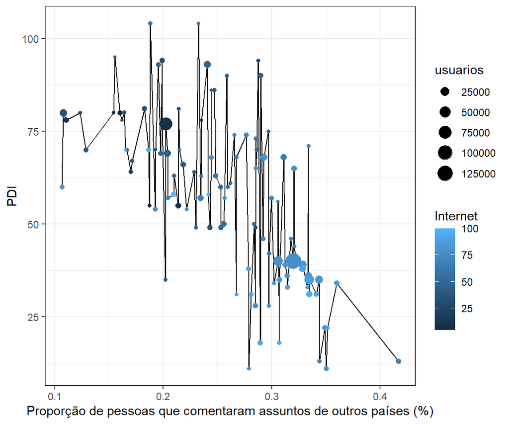

```r
    ggplot(filtered, mapping = aes(x = comentaram_prop, y = PDI)) +
    geom_line() +
    geom_point(aes(color = Internet, size = usuarios)) +
    labs(x = "Proporção de pessoas que comentaram assuntos de outros países (%)", y = "PDI")
```

As linhas estão muito juntas e não é possível identificar com clareza a qual aresta a bolinha pertence.

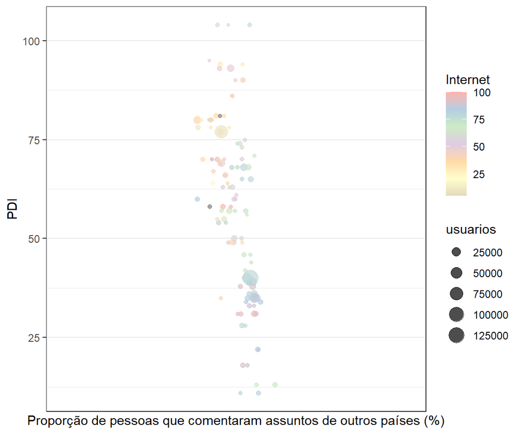

```r
    dados %>%
    ggplot(aes(x = comentaram_prop, y = PDI, color = Internet, size = usuarios)) +
    scale_color_distiller(palette="Pastel1") +
    geom_point(alpha = 0.7) +
    scale_x_discrete() +
    labs(x = "Proporção de pessoas que comentaram assuntos de outros países (%)", y = "PDI")
```

As bolinhas estão muito sobrepostas em cima das outras não permitindo uma visão clara dos pontos e as cores estão muito claras.

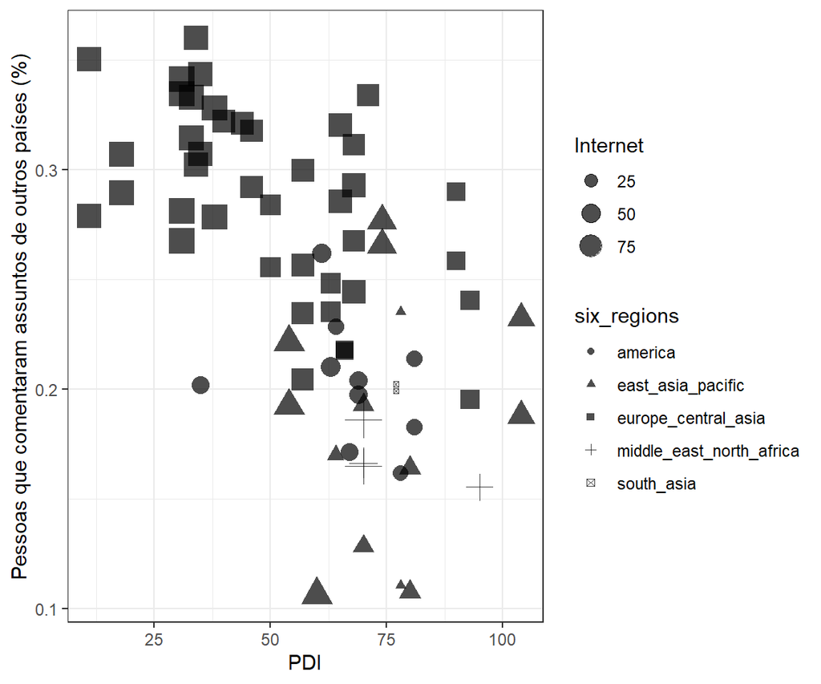

```r
    filtered %>% na.omit() %>%
    ggplot(aes(x = PDI, y = comentaram_prop, shape = six_regions, size = Internet)) +
    geom_point(alpha = .7) +
    labs(x = "PDI", y = "Pessoas que comentaram assuntos de outros países (%)")
```

Mesmo problema do plot anterior as formas estão muito sobrepostas e são da mesma cor, podendo cobrir formas menores, impendindo uma visualização clara em algumas áreas.

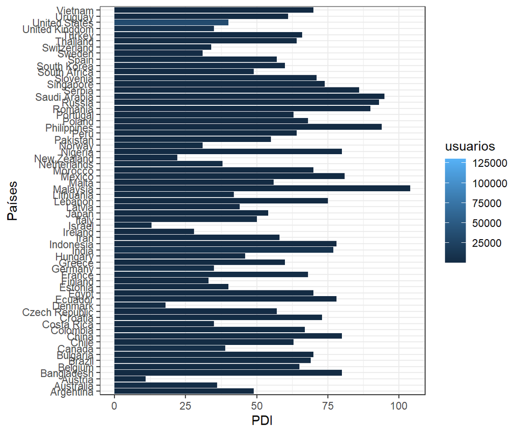

```r
    ggplot(filtered, mapping = aes(fill=usuarios, x = PDI, y = country)) +
    geom_bar(position = "dodge", stat="identity") +
    labs(x = "PDI", y = "Países")
```

Nesta visualização, podemos ver que os nomes dos países estão muito próximos e os dados não estão ordenados, tornando a leitura mais difícil.

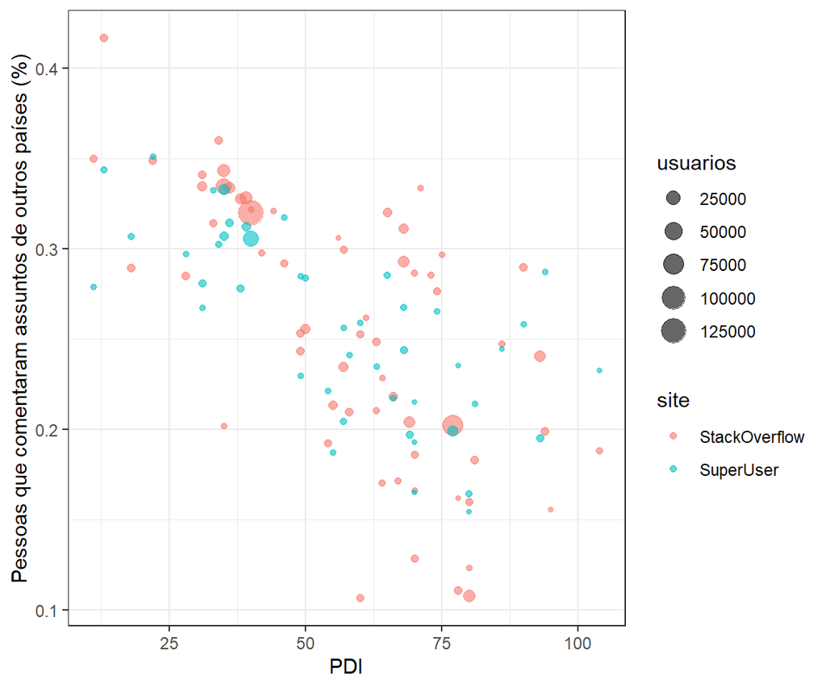

```r
ggplot(filtered, aes(x = PDI, y = comentaram_prop, color = site, size = usuarios)) + geom_point(alpha = .6) +
    labs(x = "PDI", y = "Pessoas que comentaram assuntos de outros países (%)")
```

A visualização mostra os dados dos sites no mesmo gráfico o que pode fazer com que as bolinhas se sobreponham, atrapalhando a interpretação da imagem.

## Bônus

Inclua o continente dos países (`six_regions`) na visualização.

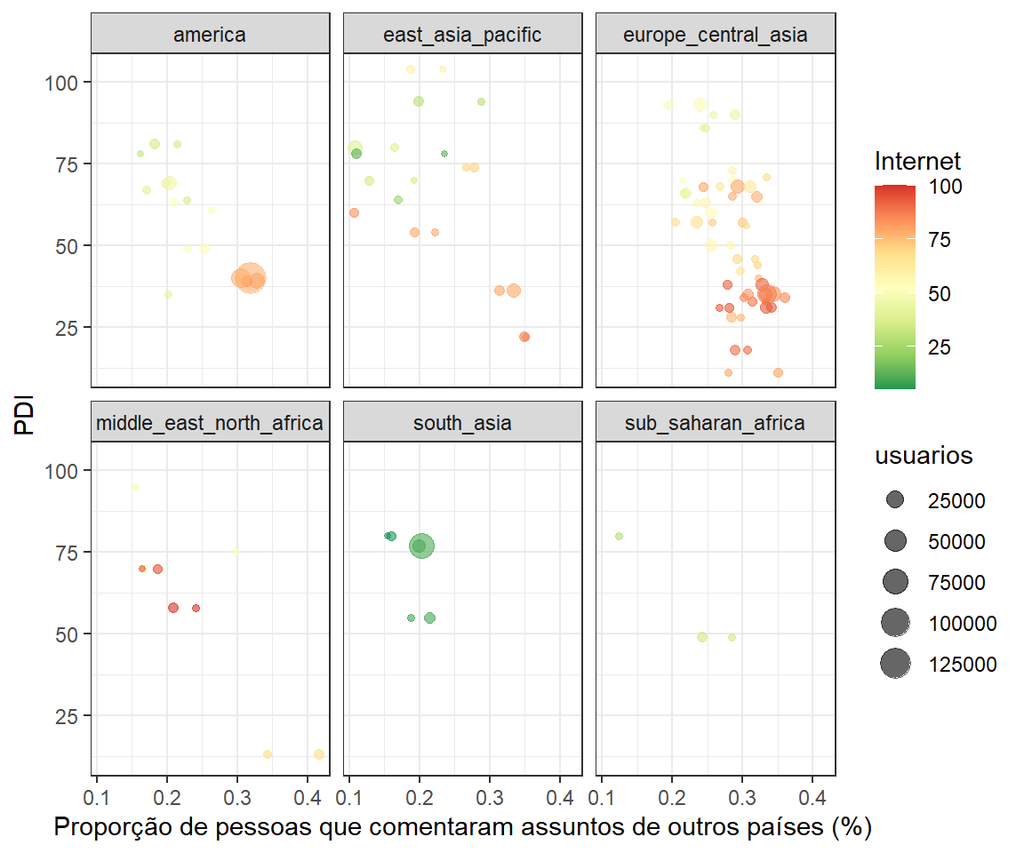

```r
    ggplot(filtered, mapping = aes(x = comentaram_prop, y = PDI, color = Internet, size = usuarios)) + geom_point(alpha = .6) +
    labs(x = "Proporção de pessoas que comentaram assuntos de outros países (%)", y = "PDI") + scale_color_distiller(palette="RdYlGn") +
    facet_wrap(~six_regions)
```